# Estimating the Reproductive Number of COVID-19

Louis Rossouw

2020-06-13

*THIS WORK IS YET TO BE REVIEWED*

# 1 Introduction

This paper contains estimates for the reproductive number $R_{t,m}$ over time $t$ in various countries $m$. It also shows the same for provinces within South Africa.. This is done using the methodology as described in [1]. These have been implemented in R using `EpiEstim` package [2] which is what is used here.

This paper and it’s results should be updated roughly daily and [is available online](https://lrossouw.github.io/covid-19/estimating_r.nb.html?utm_source=paper&utm_medium=paper_url&utm_campaign=week2).

# 2 Updates

As this paper is updated over time this section will summarise significant changes. The code producing this paper is tracked using Git. The Git commit hash for this project at the time of generating this paper was 7cd1476006e5d650fab9f9d63a9d00bd0ec2dd6b.

**2020-06-12**

- Initial version.

**2020-06-13**

- Combine the version for South Africa and other countries.

# 3 Libraries

The project uses the following libraries.

```r
require(EpiEstim)
require(EnvStats)
require(ggplot2)
require(ggpubr)
require(lubridate)
require(utils)
require(httr)
require(dplyr)
require(tidyr)
require(scales)
```

# 4 Countries

All countries available in the data will be analysed but also the provinces of South Africa. This paper produces charts for the following countries only:

```r
countries = c("Brazil", "Canada", "Chile", "India", "Ireland", "Italy", "Peru", "South_Africa", "Spain", "United_Kingdom")
```

# 5 Data

## 5.1 South Africa

### 5.1.1 Download

Data is downloaded from the Git repository associated with [3].

```r
# Provincial Deaths
GET(url = "https://raw.githubusercontent.com/dsfsi/covid19za/master/data/covid19za_provincial_cumulative_timeline_deaths.csv", write_disk("covid19za_provincial_cumulative_timeline_deaths.csv",
    overwrite = TRUE))
```

```
Response [https://raw.githubusercontent.com/dsfsi/covid19za/master/data/covid19za_provincial_cumulative_timeline_deaths.csv]
  Date: 2020-06-13 21:50
  Status: 200
  Content-Type: text/plain; charset=utf-8
  Size: 7.3 kB
<ON DISK>  C:\Users\lrossou\Desktop\COVID-19\rt_estimates\covid19za_provincial_cumulative_timeline_deaths.csv
```

```r
# Provincial Cases
GET(url = "https://raw.githubusercontent.com/dsfsi/covid19za/master/data/covid19za_provincial_cumulative_timeline_confirmed.csv", write_disk("covid19za_provincial_cumulative_timeline_confirmed.csv",
    overwrite = TRUE))
```

```
Response [https://raw.githubusercontent.com/dsfsi/covid19za/master/data/covid19za_provincial_cumulative_timeline_confirmed.csv]
  Date: 2020-06-13 21:50
  Status: 200
  Content-Type: text/plain; charset=utf-8
  Size: 9.2 kB
<ON DISK>  C:\Users\lrossou\Desktop\COVID-19\rt_estimates\covid19za_provincial_cumulative_timeline_confirmed.csv
```

### 5.1.2 Data preperation

First read in the data from the downloaded comma-separated values text file.

```r
# Read from CSVs above
data_za_cases <- read.csv("covid19za_provincial_cumulative_timeline_confirmed.csv", stringsAsFactors = FALSE)
data_za_deaths <- read.csv("covid19za_provincial_cumulative_timeline_deaths.csv", stringsAsFactors = FALSE)
```

In the case data file row 21 and 32 contain no provincial details. We estimated it by spreading the national total to the provinces in proportion to a mixture of the prior day and the next day.

```r
data_za_cases[21, c("EC", "FS", "GP", "KZN", "LP", "MP", "NC", "NW", "WC", "UNKNOWN")] <- colSums(data_za_cases[c(20, 22), c("EC", "FS", "GP", "KZN",
    "LP", "MP", "NC", "NW", "WC", "UNKNOWN")])/sum(data_za_cases[c(20, 22), ]$total) * data_za_cases[21, ]$total
data_za_cases[32, c("EC", "FS", "GP", "KZN", "LP", "MP", "NC", "NW", "WC", "UNKNOWN")] <- colSums(data_za_cases[c(31, 33), c("EC", "FS", "GP", "KZN",
    "LP", "MP", "NC", "NW", "WC", "UNKNOWN")])/sum(data_za_cases[c(31, 33), ]$total) * data_za_cases[32, ]$total
```

The following function will be applied to case and death data. In this function the following occurs:

1. Scale up the per province data for unknown values.
2. This results in provincial data which are not whole numbers. These are rounded to the nearest whole number.
3. A `SA` column is added as the sum of the new per province data.
4. Data is formatted and disaggregated such that item represents the incremental cases or deaths rather than cumulative figures.
5. Data is filled with data (albeit with 0 cases or deaths) for all dates in the range.
6. Any incremental case or death counts that are negative are zeroeised.
7. New cumulative figures are calculated.

```r
fix_data_za <- function(data_za, start_date = as.Date("2020-03-01"), end_date = as.Date("2020-03-31")) {
    # Scale provinces by scale factor (assume unknown are in proportion)
    data_za[, c("EC", "FS", "GP", "KZN", "LP", "MP", "NC", "NW", "WC")] <- data_za[, c("EC", "FS", "GP", "KZN", "LP", "MP", "NC", "NW", "WC")] * (1 +
        data_za$UNKNOWN/rowSums(data_za[, c("EC", "FS", "GP", "KZN", "LP", "MP", "NC", "NW", "WC")]))

    # Only select columns we need
    data_za <- data_za %>% select("date", "EC", "FS", "GP", "KZN", "LP", "MP", "NC", "NW", "WC")
    data_za$date <- as.Date(data_za$date, "%d-%m-%Y")

    # Round data so we have integer cases
    data_za[, c("EC", "FS", "GP", "KZN", "LP", "MP", "NC", "NW", "WC")] <- round(data_za[, c("EC", "FS", "GP", "KZN", "LP", "MP", "NC", "NW", "WC")],
        0)

    # Calculate a new SA column
    data_za$SA <- rowSums(data_za[, c("EC", "FS", "GP", "KZN", "LP", "MP", "NC", "NW", "WC")])

    # 'Melt' the data
    data_za <- pivot_longer(data_za, cols = c("EC", "FS", "GP", "KZN", "LP", "MP", "NC", "NW", "WC", "SA"), names_to = "province", values_to = "count")

    # Getting daily data from the cumulative data set
    data_za = data_za %>% group_by(province) %>% arrange(date) %>% mutate(count = count - lag(count, default = 0)) %>% ungroup()

    # add missing dates
    all_dates <- expand_grid(date = seq(start_date, end_date, 1), province = levels(as.factor(data_za$province)))

    # join
    data_za <- left_join(all_dates, data_za, by = c("date", "province"))

    # province factor
    data_za$province <- as.factor(data_za$province)

    # 0 for NAs
    data_za$count <- ifelse(is.na(data_za$count), 0, data_za$count)

    # remove negatives
    data_za$count <- ifelse(data_za$count < 0, 0, data_za$count)

    # get cumulative counts
    data_za <- data_za %>% group_by(province) %>% mutate(cumulative_count = cumsum(count)) %>% ungroup()

    return(data_za)
}
```

Below we use the function above to process deaths and cases and then combine them into a single dataset.

```r
start_date <- min(as.Date(data_za_cases$date, "%d-%m-%Y"))
end_date <- max(as.Date(data_za_cases$date, "%d-%m-%Y"))
data_za_cases <- fix_data_za(data_za_cases, start_date = start_date, end_date = end_date)
data_za_deaths <- fix_data_za(data_za_deaths, start_date = start_date, end_date = end_date)

data_za_cases <- cbind("cases", data_za_cases)
data_za_deaths <- cbind("deaths", data_za_deaths)
colnames(data_za_cases)[1] <- "type"
colnames(data_za_deaths)[1] <- "type"

# combined
data_za <- rbind(data_za_cases, data_za_deaths)

# remove data sets no longer needed
rm("data_za_cases", "data_za_deaths", "start_date", "end_date", "fix_data_za")
```

## 5.2 Other countries

### 5.2.1 Download

Data for other countries are downloaded from [4].

```r
GET(url = "https://opendata.ecdc.europa.eu/covid19/casedistribution/csv", write_disk("ecdc_casedistribution.csv", overwrite = TRUE))
```

```
Response [https://opendata.ecdc.europa.eu/covid19/casedistribution/csv/]
  Date: 2020-06-13 21:50
  Status: 200
  Content-Type: application/octet-stream
  Size: 1.36 MB
<ON DISK>  C:\Users\lrossou\Desktop\COVID-19\rt_estimates\ecdc_casedistribution.csv
```

### 5.2.2 Data preperation

First read in the data from the downloaded comma-separated values text file.

```r
# Read from CSVs above
data <- read.csv("ecdc_casedistribution.csv", stringsAsFactors = FALSE)
```

Update data by doing the following:

1. Format dates.
2. Set column names.
3. Add data where dates were skipped (with 0 cases or deaths)
4. “Melt” the data down.
5. Set fields as factors as needed.
6. Get cumulative numbers.

```r
# get date
data$date <- as.Date(data$dateRep, format = "%d/%m/%Y")

# get cases and deaths
data <- data %>% select(continentExp, date, countriesAndTerritories, cases, deaths)

# column names
colnames(data) <- c("continent", "date", "country", "cases", "deaths")

# add 0 data for dates that were skipped
for (c in levels(as.factor(data$country))) {
    c_dates <- (data %>% filter(country == c))$date
    check_dates <- seq(min(c_dates), max(c_dates), by = 1)
    missing_dates <- check_dates[!check_dates %in% c_dates]
    continet <- (data %>% filter(country == c))$continent[1]
    if (length(missing_dates) > 0) {
        missing_data <- data.frame(continent = continet, date = missing_dates, country = rep(c, length(missing_dates)), cases = rep(0, length(missing_dates)),
            deaths = rep(0, length(missing_dates)))
        data <- rbind(data, missing_data)
    }
}

# 'Melt' the data
data <- pivot_longer(data, cols = c("cases", "deaths"), names_to = "type", values_to = "count")

# fields as factors
data$country <- as.factor(data$country)
data$type <- as.factor(data$type)

# make sure it is a data frame
data <- as.data.frame(data)

# zeroise counts below 0
data$count <- ifelse(data$count < 0, 0, data$count)

# order and get group by
data <- data %>% group_by(country, type) %>% arrange(country, type, date) %>% mutate(cumulative_count = cumsum(count)) %>% ungroup()
```

## 5.3 Combine South African data with other data

To simplify further analysis it’s easier to combine all data in a single dataset:

```r
# Add a 'continent' field to data_za and combine
data_za <- cbind("SA", data_za)
colnames(data_za)[1] <- "continent"
colnames(data_za)[4] <- "country"
data <- rbind(data, data_za)

# remove all objects except the final data set and the list of countries
rm(list = ls()[!ls() %in% c("data", "countries")])
```

# 6 Basic Exploration

## 6.1 South Africa

Below we plot cumulative case count on a log scale by province:

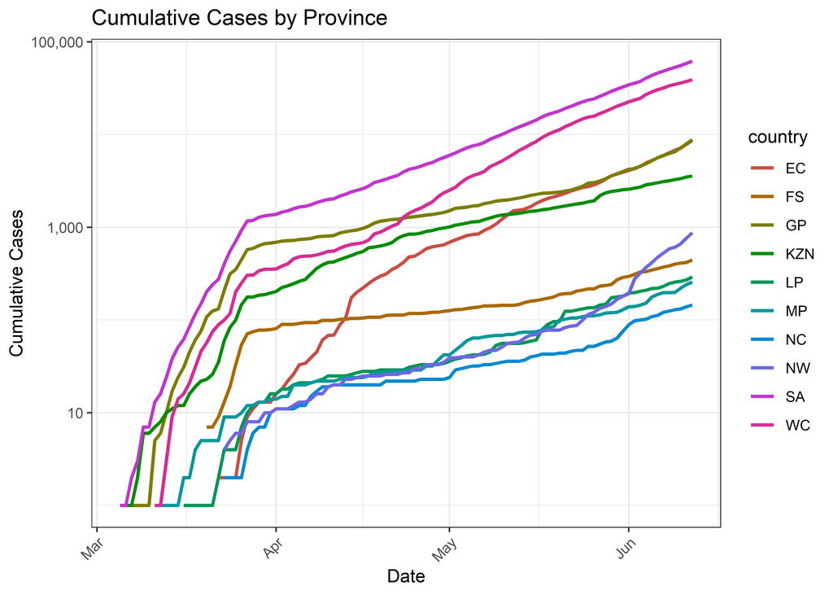

```r
ggplot(data %>% filter(continent == "SA" & type == "cases" & cumulative_count > 0), aes(x = date, y = cumulative_count)) + geom_line(aes(color = country),
    size = 1) + scale_y_log10(labels = comma) + ggtitle("Cumulative Cases by Province") + xlab("Date") + ylab("Cumulative Cases") + theme_bw() + theme(axis.text.x = element_text(angle = 45,
    hjust = 1), legend.position = "right") + guides(fill = guide_legend(ncol = 1)) + scale_color_hue(l = 50)
```

Below we plot the cumulative deaths by province on a log scale:

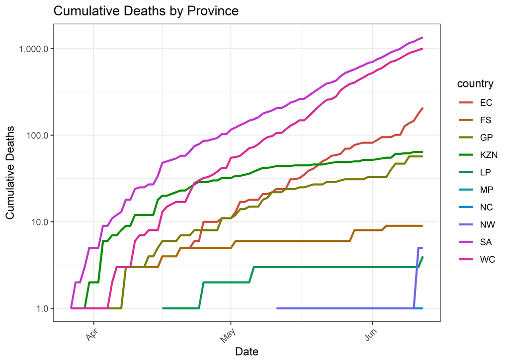

```r
ggplot(data %>% filter(continent == "SA" & type == "deaths" & cumulative_count > 0), aes(x = date, y = cumulative_count)) + geom_line(aes(color = country),
    size = 1) + scale_y_log10(labels = comma) + ggtitle("Cumulative Deaths by Province") + xlab("Date") + ylab("Cumulative Deaths") + theme_bw() + theme(axis.text.x = element_text(angle = 45,
    hjust = 1), legend.position = "right") + guides(fill = guide_legend(ncol = 1)) + scale_color_hue(l = 50)
```

## 6.2 Other Countries

Below we plot cumulative case count on a log scale by country:

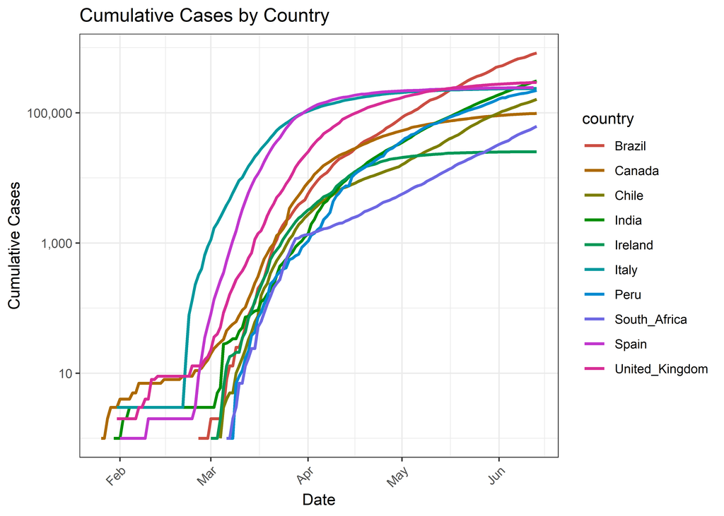

```r
ggplot(data %>% filter(continent != "SA" & type == "cases" & country %in% countries & cumulative_count > 0), aes(x = date, y = cumulative_count)) + geom_line(aes(color = country),
    size = 1) + scale_y_log10(labels = comma) + ggtitle("Cumulative Cases by Country") + xlab("Date") + ylab("Cumulative Cases") + theme_bw() + theme(axis.text.x = element_text(angle = 45,
    hjust = 1), legend.position = "right") + guides(fill = guide_legend(ncol = 1)) + scale_color_hue(l = 50)
```

Below we plot the cumulative deaths by country on a log scale:

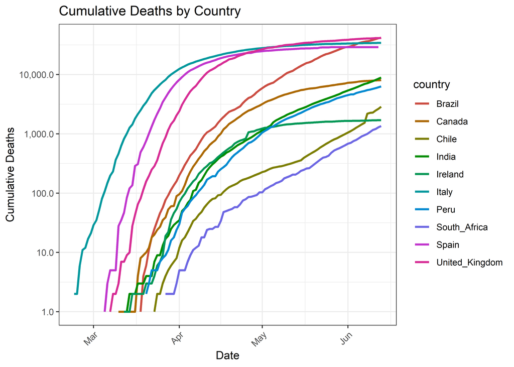

```r
ggplot(data %>% filter(continent != "SA" & type == "deaths" & country %in% countries & cumulative_count > 0), aes(x = date, y = cumulative_count)) +
    geom_line(aes(color = country), size = 1) + scale_y_log10(labels = comma) + ggtitle("Cumulative Deaths by Country") + xlab("Date") + ylab("Cumulative Deaths") +
    theme_bw() + theme(axis.text.x = element_text(angle = 45, hjust = 1), legend.position = "right") + guides(fill = guide_legend(ncol = 1)) + scale_color_hue(l = 50)
```

# 7 Serial Interval

To do further analysis an serial interval assumption is needed. The serial interval is taken from [5]. It’s assumed to be Gamma distributed with mean of 6.48 and standard deviation of 3.83. This corresponds to the effective infectiousness of an individual since acquiring the infection themselves.

We plot this serial distribution below:

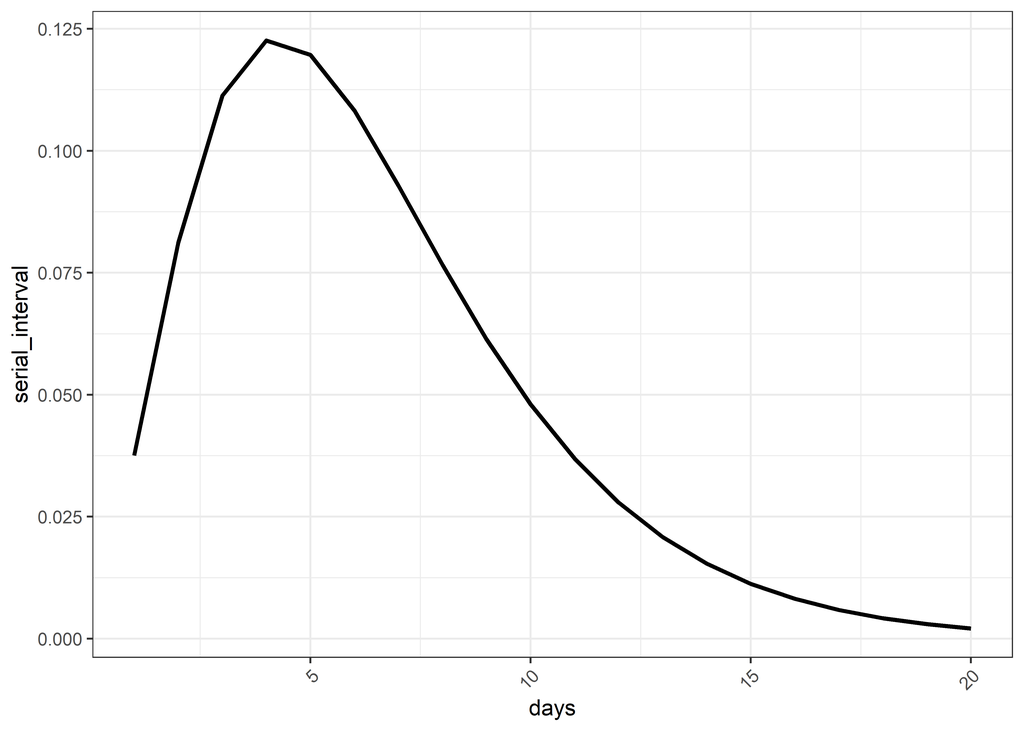

```r
si_mean <- 6.48
si_sd <- 3.83
si_cv <- si_sd/si_mean

serial_interval = rep(0, 1)
serial_interval[1] = (pgammaAlt(1.5, si_mean, si_cv) - pgammaAlt(0, si_mean, si_cv))
for (i in 2:50) {
    serial_interval[i] = (pgammaAlt(i + 0.5, si_mean, si_cv) - pgammaAlt(i - 0.5, si_mean, si_cv))
}
ggplot(data.frame(days = seq(1, 20, 1), serial_interval = serial_interval[1:20]), aes(y = serial_interval, x = days)) + geom_line(size = 1) + theme_bw() +
    theme(axis.text.x = element_text(angle = 45, hjust = 1), legend.position = "right") + guides(fill = guide_legend(ncol = 1)) + scale_color_hue(l = 50)
```

# 8 Estimate $R_{t,m}$ values by week

## 8.1 Estimation Routing

The following code works backwards and fits $R_{t,m}$ values for whole weeks (ending on the last date in the data) using the `EpiEstim` package. Using deaths or infection the as the cases in the puts the estimate of $R_{t,m}$ as at the date of the cases being tracked.

So $t$ is based on the date of reporting (be that cases or deaths) and $m$ is the country or province. Two values are estimated for each country:

1. $R_{t,m}^{cases}$ is the reproductive number implied by the cases reported at time $t$ in country $m$.
2. $R_{t,m}^{deaths}$ is the reproductive number implied by the deaths reported at time $t$ in country $m$.

Note that the time periods are left unadjusted, though in reality the $R_{t,m}^{deaths}$ should be shifted back approximately 2 weeks relative to $R_{t,m}^{cases}$.

```r
Rt_data <- NULL
for (c in levels(data$country)) {
    for (t in levels(data$type)) {
        # filter out country data of type t
        c_data <- data %>% filter(country == c & type == t)

        # vector of count of cases/deaths
        I <- c_data$count

        # t=1 corresponds to this date:
        t1_date <- min(c_data$date)

        # the day after the first case/death:
        t_start_date <- min((c_data %>% filter(count > 0))$date) + 1
        t_start <- min(seq(1, length(I))[I > 0]) + 1

        # last day of cases/deaths
        t_end <- length(I)
        t_end_date <- t1_date + (t_end - 1)

        # how many full weeks do we have
        full_weeks <- floor((t_end - t_start)/7)

        # only continue if we have 1 full week or more
        if (full_weeks > 0) {
            # then divide period into weeks
            T.Start <- seq(t_end - 7 * full_weeks, t_end - 7, by = 7)
            T.End <- T.Start + 7

            # estimate $R_{t,m}^{type}$ for each week:
            c_Rt <- EstimateR(I, T.Start = T.Start, T.End = T.End, Mean.SI = si_mean, Std.SI = si_sd, method = "ParametricSI")$R

            # count cases
            c_data$week <- floor(as.numeric(c_data$date - (t1_date + T.Start[1]))/7)
            c_data$dd <- c(0, c_data$date[2:nrow(c_data)] - c_data$date[1:(nrow(c_data) - 1)])
            c_agg_data <- c_data %>% filter(week >= 0) %>% group_by(week) %>% summarise(count = sum(count)) %>% ungroup()

            # add country and type designations
            c_Rt <- cbind(c_data$continent[1], c, t, c_Rt, c_agg_data$count)

            # and add dates
            c_Rt$date_start <- t1_date + c_Rt$T.Start
            c_Rt$date_end <- t1_date + c_Rt$T.End - 1

            # combine the results
            if (is.null(Rt_data)) {
                Rt_data <- c_Rt
            } else {
                Rt_data <- rbind(Rt_data, c_Rt)
            }
        }
    }
}
```

## 8.2 Prepping data for tabulation and plots

Below we prep column headings and prepare CI data:

```r
# Column names
colnames(Rt_data) <- c("continent", "country", "type", "t_start", "t_end", "Rt_mean", "Rt_std", "Rt_li_95", "Rt_li_90", "Rt_li_50", "Rt_median", "Rt_ui_50",
    "Rt_ui_90", "Rt_ui_95", "count", "date_start", "date_end")

# mid week data point
Rt_data$date_mid <- Rt_data$date_start + (Rt_data$date_end - Rt_data$date_start)/2

# split out CI data into different dataset
Rt_ci_data <- NULL
for (ci in c("50", "90", "95")) {
    r <- data.frame(country = Rt_data$country, type = Rt_data$type, ci = rep(paste0(ci, "%"), nrow(Rt_data)), date_mid = Rt_data$date_mid, Rt_mean = Rt_data$Rt_mean,
        Rt_li = Rt_data[[paste0("Rt_li_", ci)]], Rt_ui = Rt_data[[paste0("Rt_ui_", ci)]])
    Rt_ci_data <- rbind(r, Rt_ci_data)
}

# remove what is not needed
rm(list = ls()[!ls() %in% c("data", "countries", "Rt_data", "Rt_ci_data")])
```

Write to comma-separated value file:

```r
write.csv(Rt_data, "Rt_data.csv", row.names = FALSE)
```

You can review the above file here.

# 9 Current $R_{t,m}$ estimates

Below current (last weekly) $R_{t,m}$ estimates are tabulated. To so the data first needs to be prepared:

```r
# find the last estimates
last_dates <- Rt_data %>% group_by(country, type) %>% summarise(date_mid = max(date_mid)) %>% ungroup()

# construct a table with nice fields names
table <- inner_join(last_dates, Rt_data, by = c("country", "type", "date_mid"))
table <- table %>% select(continent, country, type, count, date_end, Rt_li_95, Rt_mean, Rt_ui_95)
```

## 9.1 South Africa

```r
knitr::kable((table %>% filter(continent == "SA"))[, -1], format.args = list(big.mark = ","), digits = 1, col.names = c("Country", "Estimated Type",
    "Count (Last Week)", "Week Ending", "R - Lower CI", "R - Mean", "R - Uppper CI"))
```

| Country | Estimated Type | Count (Last Week) | Week Ending | R - Lower CI | R - Mean | R - Uppper CI |
| --- | --- | --- | --- | --- | --- | --- |
| EC | cases | 3,383 | 2020-06-12 | 1.7 | 1.8 | 1.8 |
| EC | deaths | 113 | 2020-06-12 | 2.8 | 3.3 | 4.0 |
| FS | cases | 99 | 2020-06-12 | 0.9 | 1.1 | 1.4 |
| FS | deaths | 0 | 2020-06-12 | 0.0 | 0.7 | 2.4 |
| GP | cases | 3,574 | 2020-06-12 | 1.9 | 2.0 | 2.0 |
| GP | deaths | 17 | 2020-06-12 | 1.2 | 1.9 | 2.7 |
| KZN | cases | 641 | 2020-06-12 | 1.0 | 1.1 | 1.2 |
| KZN | deaths | 9 | 2020-06-12 | 0.6 | 1.2 | 2.1 |
| LP | cases | 73 | 2020-06-12 | 1.1 | 1.4 | 1.7 |
| LP | deaths | 1 | 2020-06-12 | 1.2 | 10.0 | 27.8 |
| MP | cases | 80 | 2020-06-12 | 1.5 | 1.9 | 2.2 |
| NC | cases | 36 | 2020-06-12 | 0.7 | 1.0 | 1.3 |
| NC | deaths | 0 | 2020-06-12 | 0.1 | 4.5 | 16.7 |
| NW | cases | 457 | 2020-06-12 | 1.5 | 1.7 | 1.8 |
| NW | deaths | 4 | 2020-06-12 | 6.0 | 18.4 | 37.8 |
| SA | cases | 18,493 | 2020-06-12 | 1.3 | 1.3 | 1.3 |
| SA | deaths | 446 | 2020-06-12 | 1.3 | 1.4 | 1.6 |
| WC | cases | 10,156 | 2020-06-12 | 1.1 | 1.1 | 1.1 |
| WC | deaths | 301 | 2020-06-12 | 1.1 | 1.2 | 1.3 |

## 9.2 Other Countries

The table below contains $R_{t,m}$ estimates for the last week available. These estimates are based either on cases or deaths and a 95% confidence interval is shown.

```r
knitr::kable((table %>% filter(continent != "SA" & country %in% countries))[, -1], format.args = list(big.mark = ","), digits = 1, col.names = c("Country",
    "Estimated Type", "Count (Last Week)", "Week Ending", "R - Lower CI", "R - Mean", "R - Uppper CI"))
```

| Country | Estimated Type | Count (Last Week) | Week Ending | R - Lower CI | R - Mean | R - Uppper CI |
| --- | --- | --- | --- | --- | --- | --- |
| Brazil | cases | 183,048 | 2020-06-13 | 1.1 | 1.1 | 1.1 |
| Brazil | deaths | 6,802 | 2020-06-13 | 1.0 | 1.0 | 1.0 |
| Canada | cases | 3,608 | 2020-06-13 | 0.7 | 0.7 | 0.7 |
| Canada | deaths | 346 | 2020-06-13 | 0.5 | 0.6 | 0.6 |
| Chile | cases | 38,347 | 2020-06-13 | 1.1 | 1.1 | 1.2 |
| Chile | deaths | 1,422 | 2020-06-13 | 1.7 | 1.8 | 1.9 |
| India | cases | 72,336 | 2020-06-13 | 1.2 | 1.2 | 1.2 |
| India | deaths | 2,242 | 2020-06-13 | 1.3 | 1.3 | 1.4 |
| Ireland | cases | 87 | 2020-06-13 | 0.3 | 0.4 | 0.4 |
| Ireland | deaths | 35 | 2020-06-13 | 0.8 | 1.1 | 1.5 |
| Italy | cases | 1,774 | 2020-06-13 | 0.8 | 0.8 | 0.9 |
| Italy | deaths | 449 | 2020-06-13 | 0.8 | 0.9 | 0.9 |
| Peru | cases | 33,349 | 2020-06-13 | 0.9 | 0.9 | 0.9 |
| Peru | deaths | 1,146 | 2020-06-13 | 1.1 | 1.2 | 1.2 |
| South_Africa | cases | 18,493 | 2020-06-13 | 1.3 | 1.3 | 1.3 |
| South_Africa | deaths | 446 | 2020-06-13 | 1.3 | 1.4 | 1.6 |
| Spain | cases | 2,231 | 2020-06-12 | 0.8 | 0.8 | 0.9 |
| Spain | deaths | 2 | 2020-06-12 | 0.0 | 0.0 | 0.1 |
| United_Kingdom | cases | 9,639 | 2020-06-13 | 0.8 | 0.8 | 0.8 |
| United_Kingdom | deaths | 1,220 | 2020-06-13 | 0.7 | 0.7 | 0.8 |

## 9.3 Top 10s

Below we show various extremes of $R_{t,m}$ where counts (deaths or cases) exceed 50 in the last week.

### 9.3.1 Lowest $R_{t,m}$ based on Deaths

```r
knitr::kable((table %>% filter(continent != "SA" & type == "deaths" & count > 50) %>% arrange(Rt_mean))[1:10, -1], format.args = list(big.mark = ","),
    digits = 1, col.names = c("Country", "Estimated Type", "Count (Last Week)", "Week Ending", "R - Lower CI", "R - Mean", "R - Uppper CI"))
```

| Country | Estimated Type | Count (Last Week) | Week Ending | R - Lower CI | R - Mean | R - Uppper CI |
| --- | --- | --- | --- | --- | --- | --- |
| Panama | deaths | 51 | 2020-06-13 | 0.4 | 0.5 | 0.6 |
| Canada | deaths | 346 | 2020-06-13 | 0.5 | 0.6 | 0.6 |
| Belgium | deaths | 80 | 2020-06-13 | 0.5 | 0.6 | 0.7 |
| France | deaths | 263 | 2020-06-13 | 0.6 | 0.7 | 0.8 |
| United_Kingdom | deaths | 1,220 | 2020-06-13 | 0.7 | 0.7 | 0.8 |
| Turkey | deaths | 130 | 2020-06-13 | 0.7 | 0.8 | 0.9 |
| Germany | deaths | 135 | 2020-06-13 | 0.7 | 0.8 | 0.9 |
| Sweden | deaths | 215 | 2020-06-13 | 0.8 | 0.9 | 1.0 |
| Italy | deaths | 449 | 2020-06-13 | 0.8 | 0.9 | 0.9 |
| United_States_of_America | deaths | 5,526 | 2020-06-13 | 0.9 | 0.9 | 0.9 |

### 9.3.2 Lowest $R_{t,m}$ based on Cases

```r
knitr::kable((table %>% filter(continent != "SA" & type == "cases" & count > 50) %>% arrange(Rt_mean))[1:10, -1], format.args = list(big.mark = ","),
    digits = 1, col.names = c("Country", "Estimated Type", "Count (Last Week)", "Week Ending", "R - Lower CI", "R - Mean", "R - Uppper CI"))
```

| Country | Estimated Type | Count (Last Week) | Week Ending | R - Lower CI | R - Mean | R - Uppper CI |
| --- | --- | --- | --- | --- | --- | --- |
| Sri_Lanka | cases | 79 | 2020-06-13 | 0.2 | 0.3 | 0.4 |
| Djibouti | cases | 318 | 2020-06-13 | 0.3 | 0.4 | 0.4 |
| Ireland | cases | 87 | 2020-06-13 | 0.3 | 0.4 | 0.4 |
| Maldives | cases | 120 | 2020-06-13 | 0.4 | 0.5 | 0.6 |
| Malawi | cases | 72 | 2020-06-13 | 0.4 | 0.5 | 0.6 |
| Tajikistan | cases | 532 | 2020-06-13 | 0.6 | 0.7 | 0.7 |
| Canada | cases | 3,608 | 2020-06-13 | 0.7 | 0.7 | 0.7 |
| South_Sudan | cases | 353 | 2020-06-13 | 0.7 | 0.7 | 0.8 |
| Uganda | cases | 129 | 2020-06-13 | 0.6 | 0.8 | 0.9 |
| Hungary | cases | 83 | 2020-06-13 | 0.6 | 0.8 | 0.9 |

### 9.3.3 Highest $R_{t,m}$ based on Deaths

```r
knitr::kable((table %>% filter(continent != "SA" & type == "deaths" & count > 50) %>% arrange(-Rt_mean))[1:10, -1], format.args = list(big.mark = ","),
    digits = 1, col.names = c("Country", "Estimated Type", "Count (Last Week)", "Week Ending", "R - Lower CI", "R - Mean", "R - Uppper CI"))
```

| Country | Estimated Type | Count (Last Week) | Week Ending | R - Lower CI | R - Mean | R - Uppper CI |
| --- | --- | --- | --- | --- | --- | --- |
| Cameroon | deaths | 70 | 2020-06-13 | 2.7 | 3.4 | 4.3 |
| Chile | deaths | 1,422 | 2020-06-13 | 1.7 | 1.8 | 1.9 |
| Iraq | deaths | 211 | 2020-06-13 | 1.5 | 1.8 | 2.0 |
| Afghanistan | deaths | 137 | 2020-06-13 | 1.4 | 1.6 | 1.9 |
| Argentina | deaths | 153 | 2020-06-13 | 1.3 | 1.5 | 1.7 |
| Guatemala | deaths | 135 | 2020-06-13 | 1.3 | 1.5 | 1.7 |
| South_Africa | deaths | 446 | 2020-06-13 | 1.3 | 1.4 | 1.6 |
| Moldova | deaths | 62 | 2020-06-13 | 1.1 | 1.4 | 1.7 |
| Colombia | deaths | 400 | 2020-06-13 | 1.3 | 1.4 | 1.5 |
| Saudi_Arabia | deaths | 251 | 2020-06-13 | 1.2 | 1.4 | 1.5 |

### 9.3.4 Highest $R_{t,m}$ based on Cases

```r
knitr::kable((table %>% filter(continent != "SA" & type == "cases" & count > 50) %>% arrange(-Rt_mean))[1:10, -1], format.args = list(big.mark = ","),
    digits = 1, col.names = c("Country", "Estimated Type", "Count (Last Week)", "Week Ending", "R - Lower CI", "R - Mean", "R - Uppper CI"))
```

| Country | Estimated Type | Count (Last Week) | Week Ending | R - Lower CI | R - Mean | R - Uppper CI |
| --- | --- | --- | --- | --- | --- | --- |
| Eswatini | cases | 167 | 2020-06-13 | 2.7 | 3.1 | 3.6 |
| Bulgaria | cases | 523 | 2020-06-13 | 2.4 | 2.6 | 2.8 |
| Benin | cases | 127 | 2020-06-13 | 1.9 | 2.3 | 2.7 |
| Greece | cases | 171 | 2020-06-13 | 1.9 | 2.2 | 2.6 |
| Jordan | cases | 131 | 2020-06-13 | 1.8 | 2.1 | 2.4 |
| Sao_Tome_and_Principe | cases | 141 | 2020-06-13 | 1.7 | 1.9 | 2.3 |
| Bosnia_and_Herzegovina | cases | 288 | 2020-06-13 | 1.7 | 1.9 | 2.1 |
| Costa_Rica | cases | 384 | 2020-06-13 | 1.6 | 1.7 | 1.9 |
| Libya | cases | 170 | 2020-06-13 | 1.5 | 1.7 | 1.9 |
| Zambia | cases | 210 | 2020-06-13 | 1.5 | 1.7 | 1.9 |

# 10 Result Plots

Let’s generate our plots for each country/province in a list:

```r
country_plots <- list()
for (c in levels(Rt_data$country)) {
    p1 <- ggplot(Rt_ci_data %>% filter(country == c & ci == "95%"), aes(x = date_mid, y = Rt_mean)) + geom_crossbar(position = position_dodge2(padding = 0),
        aes(ymin = Rt_li, ymax = Rt_ui, colour = type, fill = type), width = 7) + scale_fill_manual(values = c(alpha("deepskyblue4", 0.45), alpha("#8b0068",
        0.45))) + scale_colour_manual(values = c(alpha("deepskyblue4"), alpha("#8b0068"))) + scale_y_continuous(limits = c(0, 5)) + scale_x_date(date_breaks = "1 months",
        labels = date_format("%e %b")) + theme_bw() + theme(axis.text.x = element_text(angle = 45, hjust = 1), legend.position = "right") + guides(fill = guide_legend(ncol = 1)) +
        xlab("Week") + ylab(expression(R[t, m])) + ggtitle(c) + geom_hline(yintercept = 1)
    country_plots[[c]] <- p1
}
```

## 10.1 South Africa

Below we plot all the provinces:

```r
ggarrange(country_plots[["EC"]], country_plots[["FS"]], country_plots[["GP"]], country_plots[["KZN"]], country_plots[["LP"]], country_plots[["MP"]],
    country_plots[["NC"]], country_plots[["NW"]], country_plots[["WC"]], country_plots[["SA"]], ncol = 2, nrow = 5) + ggtitle("Reproductive number by province, with 95% confidence intervals")
```

[figure not shown]

## 10.2 Other Countries

Below we plot all the countries:

```r
ggarrange(country_plots[["Brazil"]], country_plots[["Canada"]], country_plots[["Chile"]], country_plots[["India"]], country_plots[["Ireland"]], country_plots[["Italy"]],
    country_plots[["Peru"]], country_plots[["South_Africa"]], country_plots[["Spain"]], country_plots[["United_Kingdom"]], ncol = 2, nrow = 5) + ggtitle("Reproductive number by country, with 95% confidence intervals")
```

[figure not shown]

## 10.3 Scatter Plot

Below we plot estimates of $R_{t,m}$ based on cases versus those based on deaths for countries where these estimates range between 0.5 and 2.

### 10.3.1 South Africa

Below we plot where there were more than 5 deaths and cases in the last week. It appears that, generally, $R_{t,m}^{cases}$ and $R_{t,m}^{deaths}$ are consistent.

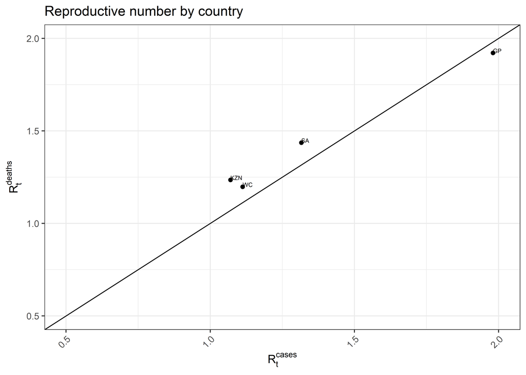

```r
sp_data <- pivot_wider(table %>% filter(count >= 5 & continent == "SA"), id_cols = c("continent", "country"), names_from = "type", values_from = "Rt_mean")

ggplot(sp_data, aes(x = cases, y = deaths)) + geom_point(aes(label = country)) + geom_text(aes(label = country), hjust = 0, vjust = 0, size = 2) + ggtitle("Reproductive number by country") +
    xlab(expression(R[t, m]^cases)) + ylab(expression(R[t, m]^deaths)) + scale_y_continuous(limits = c(0.5, 2)) + scale_x_continuous(limits = c(0.5,
    2)) + theme_bw() + theme(axis.text.x = element_text(angle = 45, hjust = 1), legend.position = "right") + guides(fill = guide_legend(ncol = 1)) +
    scale_color_hue(l = 50) + geom_abline(a = 0, b = 1)
```

### 10.3.2 Other countries

Below we plot where there were more than 25 deaths and cases in the last week. It appears that, generally, $R_{t,m}^{cases}$ and $R_{t,m}^{deaths}$ are consistent.

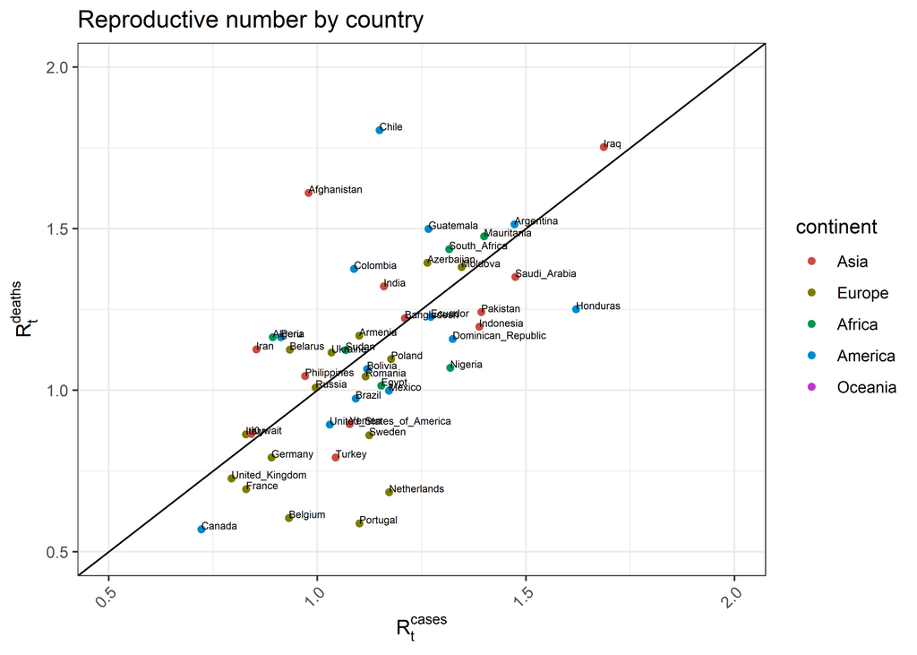

```r
sp_data <- pivot_wider(table %>% filter(count >= 25 & continent != "SA"), id_cols = c("continent", "country"), names_from = "type", values_from = "Rt_mean")

ggplot(sp_data, aes(x = cases, y = deaths)) + geom_point(aes(color = continent, label = country)) + geom_text(aes(label = country), hjust = 0, vjust = 0,
    size = 2) + ggtitle("Reproductive number by country") + xlab(expression(R[t, m]^cases)) + ylab(expression(R[t, m]^deaths)) + scale_y_continuous(limits = c(0.5,
    2)) + scale_x_continuous(limits = c(0.5, 2)) + theme_bw() + theme(axis.text.x = element_text(angle = 45, hjust = 1), legend.position = "right") +
    guides(fill = guide_legend(ncol = 1)) + scale_color_hue(l = 50) + geom_abline(a = 0, b = 1)
```

# 11 Discussion

From the basic plots it’s clear that South Africa and a few other countries appear to be on a different “slope” than European countries show. These include Brazil, Peru, Chile and India.

The above shows estimates for reproductive number using cases and deaths ($R_{t,m}^{cases}$ and $R_{t,m}^{deaths}$) for each country $m$ over time $t$ in weeks.

From the current estimates it appears that, at present, in general South African provincial estimates based on cases and deaths correspond. An exception to this may be Eastern Cape with estimates based on deaths exceeding those based on cases.

It is also clear that estimates based on cases appear to precede the movements based on deaths over time. This can be expected as, all things being equal, infections and associated cases should be a precursor to deaths.

South Africa does not compare well, and appears to have one of the highest $R_{t,m}^{deaths}$ in the world. This is higher than the $R_{t,m}^{cases}$ which may be indicative of lower testing and/or backlogs with regard to testing.

Overall it’s clear that having multiple measures of $R_{t,m}$ appears useful and monitoring it’s value is something useful.

# 12 Author

This report was prepared by Louis Rossouw. Please get in contact with Louis Rossouw if you have comments or wish to receive this regularly.

**Louis Rossouw**  
Head of Research & Analytics  
Gen Re | Life/Health Canada, South Africa, Australia, NZ, UK & Ireland  
Email: LRossouw@GenRe.com Mobile: +27 71 355 2550

*The views in this document represents that of the author and may not represent those of Gen Re. Also note that given the significant uncertainty involved with the parameters, data and methodology care should be taken with these numbers and any use of these numbers.*

# 13 References

[1] A. Cori, N. M. Ferguson, C. Fraser, and S. Cauchemez, “A new framework and software to estimate time-varying reproduction numbers during epidemics,” *American Journal of Epidemiology*, vol. 178, no. 9, pp. 1505–1512, Sep. 2013, doi: 10.1093/aje/kwt133. [Online]. Available: https://doi.org/10.1093/aje/kwt133

[2] A. Cori, *EpiEstim: EpiEstim: A package to estimate time varying reproduction numbers from epidemic curves.* 2013 [Online]. Available: https://CRAN.R-project.org/package=EpiEstim

[3] V. Marivate *et al.*, “Coronavirus disease (COVID-19) case data - South Africa.” Zenodo, 2020 [Online]. Available: https://zenodo.org/record/3888499

[4] European Centre for Disease Prevention and Control, “Data on the geographic distribution of COVID-19 cases worldwide.” European Union, 2020 [Online]. Available: https://www.ecdc.europa.eu/en/publications-data/download-todays-data-geographic-distribution-covid-19-cases-worldwide

[5] N. Ferguson *et al.*, “Report 9: Impact of non-pharmaceutical interventions (NPIs) to reduce COVID19 mortality and healthcare demand,” Imperial College London, 2020 [Online]. Available: https://www.imperial.ac.uk/mrc-global-infectious-disease-analysis/covid-19/report-9-impact-of-npis-on-covid-19/